# Guide to using the results of the diagnostic accuracy calculator

**Guide to using the results of the diagnostic accuracy calculator**

You can use the calculator to compute all the common diagnostic accuracy measures if you have a minimum set of data from a diagnostic accuracy study.

You can (and hopefully will) also use the calculator to help you interpret and apply the accuracy measures.

This is important because the ability to correctly interpret probabilities requires some study and practice. It is an unnatural activity for the human brain.

Remember, if you struggle with this, you are normal, not stupid.

### **Quick tips**

- **All tests have some false positive and some false negative results.**  
  The table and flow chart show calculated TP and TN, and FP and FN counts.  
  See the section below on the terminology of test results.
- **There is always some statistical uncertainty around an accuracy measure.**  
  The table gives 95% confidence intervals for the accuracy statistics.  
  The graphs can show ribbons of shading to visualize the statistical uncertainty.
- **Statistical uncertainty reduces as the number of samples in the evaluating study increases.**  
  Use the calculator to compute the sensitivity and specificity and predictive values of a test.  
  Repeat with the study size halved and doubled and compare the 95% confidence intervals.
- **The predictive value of a test depends on the prevalence of the condition being tested for.**  
  (Or in more technical language, the post-test probability depends on the condition's pre-test probability.)
- **The technical accuracy (sensitivity, specificity) of a test can be measured in either a case-control study, or a cohort study.**  
  See the section below on study design.
- **The clinical accuracy (predictive value) can only be measured with a cohort study.**  
  See the section below on study design.
- **The clinical value of a test depends on the accuracy of the test and the accuracy of prediction. The accuracy of prediction depends on the prevalence.**  
  See the flow chart, and the section below on clinical value.
- **The terms "prevalence" and "clinical probability" are used as synonyms on the graphs, because both are pre-test probabilities.**  
  "Prevalence" should be understood when the pre-test probability refers to the proportion of people who have a condition. Example: the test is used for screening.  
  "Clinical probability" should be understood when the pre-test probability refers to the likelihood, based on a clinical assessment, that a patient has the condition. Example: the test is used for diagnosis.
- **Predictive values are post-test probabilities.**  
  Positive predictive value (PPV) is the probability that a person who has tested positive has the condition.  
  Negative predictive value (NPV) is the probability that a person who has tested negative does not have the condition.

### Links to sections

> What is a test?  
> Other names for TP and FP (True Positive and False Positive)  
> What purposes are tests used for?  
> Why is study design relevant to test accuracy measures?  
> How is a test valued?

### What is a test?

A test (when talking about diagnostic accuracy) is something that provides a "Yes or No", "Present or Absent", "Positive or Negative", "True or False" answer to a question.

In other words, a test *for the present purposes* is a binary classification. And, when compared with a reference standard, the classifications are also binary: True or False.

This restrictive definition is useful. In practice, it is how tests are often thought of. The action informed by a test result is usually binary: act or do not act. It is a convenient starting point for understanding the measures of test accuracy.

To reflect reality, the restrictions must be eased: the classification can be into more than two groups, or expressed as a real number: as risk or a probability.

| **Test type** | **Example question** |
| --- | --- |
| A blood test for a condition. | Does the patient have malaria? |
| Medical history for a symptom | Are you short of breath? |
| Clinical examination for a feature | Is the spleen enlarged? |
| Smartphone app for tracking | Is another phone with the tracking app nearby? |

These examples illustrate that it can be important to understand the accuracy of tests that are physically quite different from the prototypical blood test.

**Accuracy of measurement of a biomarker vs accuracy of diagnosis of a condition**  
It is often useful to think of a test as diagnosing a condition, and mentally skip over the logical step from the test measuring a biomarker to diagnosing the presence of a condition.

However, it is also often essential to consider both steps.

Example 1. A test for antibodies in a sample of blood could provide an accurate measurement. However, antibodies take a week or more to be produced, and can be found for months to years after the infection has resolved. The antibody test will be highly accurate in its measurement, but as a test for current or previous infection, it will be highly inaccurate, unless used in conjunction with other clinical information.

Example 2. Two phones might recognize that they are nearby, but the people they are tracking might be elsewhere, or could be separated by a wall or screen. The accuracy of measurement of proximity may be quite different from the accuracy with which clinically significant close contact of people is identified.

Claims of accuracy therefore have to be scrutinized to make sure that the accuracy is relevant to the proposed use of the test.

Jump to top of the page

### Other names for accuracy measures

When tests are used in healthcare, their accuracy measurements are commonly called true and false positives, and true and false negatives.  
Other fields use other names that reflect their main applications. For example:

> **False positive** is also known as: type I error, false alarm, crying wolf, and false accept rate  
> **False negative** is also known as: type II error, missed detection rate, false reject rate

Jump to top of the page

### What purposes are tests used for?

A test can be used for many purposes, including:

- Diagnosis (typically implies that the pre-test probability is not very low)
- To rule a condition in
- To exclude a condition
- Screening (typically implies that the pre-test probability is low to very low)
- Epidemiology to assess the incidence and prevalence of a condition

Jump to top of the page

### Why is study design relevant to test accuracy measures?

The first bit of information the calculator needs to compute diagnostic accuracy measures is the study design that was used.

This is because data from cohort studies can be used to estimate prevalence and positive and negative predictive values, as well as sensitivity and specificity.  
However, data from case-control studies can only be used to estimate sensitivity and specificity.

#### What is the difference between case-control and cohort study designs?

A **case-control study** tests samples from two groups of people: cases who are known to have the condition and cases who do not.

A **cohort study** tests samples from from one group, the cohort, who are selected to be representative of the populations in which the test will be used.

Figure 1 may make it easier to see the difference between case-control and cohort studies.

**Case-control studies**  
**Pane a in Figure 1** shows data from two groups: samples from people who have the condition (orange), and samples from people who do not have the condition (olive green).  
When these samples are tested, the results will be either positive or negative.  
Because we know that the first group has the condition, the positive results are true (TP), and the negative results are false (FN).  
Because we know that the second group does not has the condition, the positive results are false (FP), and the negative results are true (TN).  
The data are conventionally shown in a 2x2 table, like that produced by the calculator.  
Data from the group with the condition allow sensitivity to be calculated: TP/(TP + FN).  
Data from the group without the condition allow specificity to be calculated: TN/(FP + TN).

Data from the case-control study cannot be used to calculate the prevalence (pre-test probability) of the condition in an actual population. To see this, think about a study which had 25 samples from people with the condition and 25 samples from people without the condition. In this study, 50% of the samples are from people with the condition. Now consider a second study which has 25 samples from people with the condition and 75 samples from people without the condition. So, the second study has 25% of the samples from people with the condition. The two studies give the same estimates (within statistical variation) of sensitivity and specificity. But they give very difference estimates of "prevalence", 25% and 50%, neither of which relate to a real clinical population.

However, if the pre-test probability can be estimated, the positive and negative predictive values can be calculated. The formulae are shown in Figure 1, Pane a.

**Cohort studies**  
**Pane b in Figure 1** shows samples taken from one population, with some people who have the condition (orange), and some who do not have the condition (olive green).  
These samples will be tested with both the reference test (called gold standard if it is known to be 100% accurate), and the index test.  
The index test is the test whose accuracy is being evaluated by comparing it to the reference test.

When these samples are tested with the reference and index tests, the results will be either positive or negative.  
The data are conventionally shown in a 2x2 table, like that produced by the calculator.

**Pane b in Figure 1** shows (with straight arrows) how sensitivity can be calculated with data from samples which are now known to be from people with the condition.  
Similarly, specificity is calculated with data from people now know to be without the condition.

In contrast, pane b shows (with curved arrows) how predictive values are calculated using data from the whole population. The formulae are shown in the figure.

### Figure 1. Design of case-control diagnostic accuracy studies

[figure not shown]

#### To take away

**Case-control** studies pre-select cases and controls, and can be used to estimate sensitivity and specificity. They cannot estimate prevalence and predictive values.  
Because they are simpler (and therefore cheaper) to run than cohort studies, they are usually done early in the development of a new test.  
**Cohort studies** (should) select a population similar to that in which the test is to be used in practice.  
They provide estimates of all the measures of diagnostic accuracy.

Jump to top of the page

### How is a test valued?

It is a good idea to understand the value of a test before you recommend or discuss doing it with a patient or in an epidemiological study.

### Figure 2. Flow chart for valuing a test

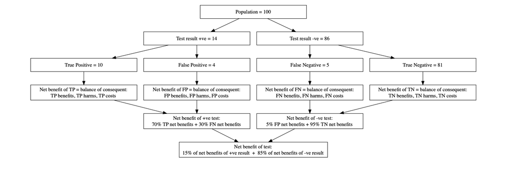

To reproduce the flowchart, use the calculator for a diagnostic accuracy case-control study that reports sensitivity = 70%, specificity 95%, study size = 100, and prevalence = 15%.  
The top half of the chart is a natural frequencies chart that sets out data from a 2x2 table in a way intended to provide a more intuitive understanding of the diagnostic accuracy counts and statistics [1, 2].  
The bottom half of the flowchart is mirror image of the top half, but showing how test results can valued.  
If we walk through the flow chart from top to bottom we will find the natural frequencies in the top half.

- The population (n = 100 in this example)
- The counts of the positive and negative test results (test +ve = 14; test -ve = 86)
- The counts of the true and false positive test results, and the false and true negative results (TP = 10, FP = 4, FN = 5, TN = 81)

Continuing the walk through the bottom half of the flow chart from top to bottom we will find the "recipes" for valuing the test.

- The first step in valuing the test is to value each of the 4 possible outcomes: true positive, false positive, false negative, and true negative.  
  For each outcome, we consider the benefits, harms, and costs that would be expected to follow from acting on this result, and then estimate the net benefit and costs.  
  This is the ideal rational approach. However, it can be difficult to identify all the relevant benefits and harms, challenging to quantify them, and taxing to assign a monetary value that would allow an arithmetic calculation of net benefit. Health economics does this routinely, and has a large literature on the methodologies. For the present purposes all we need note is that methods exist and are used to do the accounting at this level of detail.  
  In a clinical situation, it is possible (and desirable) to make a qualitative assessment of the net value of the benefits, harms, and costs of each outcome: TP, FP, FN, TN.
- The second step is to consider the net benefit of having a positive test, and the net benefit of having a negative result.  
  The temptation is to add the net benefits of each of TP, FP, FN, and TN, but this would be wrong. We need to weight each net benefit by the expected proportion of its outcome. The net benefit of an outcome weighted by its probability (expected proportion with that outcome) is called the expected net benefit.  
  The graph shows that for our example, the net benefit of having a positive test result is 70% of the net benefit of a true positive result and 30% of the net benefit of a false positive result. (If the harms consequent to a test outcome outweigh the benefits, the net benefits are negative.)  
  Again, the accounting for expected net benefit can be done arithmetically or informally.
- The third step is to consider the net benefit of having the test done.  
  As with the second step, the weighted net benefit of having a positive test result is added to the weighted net benefit of having a negative result.  
  In our example, the net benefit of doing the test is 15% of the benefit of having a positive test plus 85% of the benefit of a negative result. Again, the addition can be done arithmetically or qualitatively.

#### To take away

- The net benefit of a test is the sum of the expected net benefits of a positive result and expected net benefits of a negative result.
- The net benefit of a positive result is the sum of the expected net benefits of TP and FP results.
- The net benefit of a negative result is the sum of the expected net benefits of FN and TN results.
- The net values can be assessed quantitatively or qualitatively.  
  In clinical situations, patient and clinician would usually qualitatively assess the pros and cons of each outcome. This is often not an easy task, so a companion app is being developed to aid diagnostic decision-making.
- The world needs to be grateful to [Stanislav Yevgrafovich Petrov](https://en.wikipedia.org/wiki/Stanislav_Petrov) for knowing both the likelihood and the cost of a false acceptance by a detection system, and for then not acting on what was probably a false alarm.

Jump to top of the page

## References and resources

1. Simple tools for understanding risks: from innumeracy to insight.  
   Gigerenzer G, Edwards A.  
   BMJ. 2003;327(7417):741‐744. doi:10.1136/bmj.327.7417.741  
   [PDF](https://www.ncbi.nlm.nih.gov/pmc/articles/PMC200816/pdf/bmj32700741.pdf)
2. Using natural frequencies to improve diagnostic inferences.  
   Hoffrage U, Gigerenzer G.  
   *Acad Med*. 1998;73(5):538‐540. doi:10.1097/00001888-199805000-00024  
   [PDF](https://journals.lww.com/academicmedicine/Abstract/1998/05000/Using_natural_frequencies_to_improve_diagnostic.24.aspx)
3. How to Ease the Pain of Taking a Diagnostic Point of Care Test to the Market: A Framework for Evidence Development.  
   Graziadio, S., Winter, A., Lendrem, B. C., Suklan, J., Jones, W. S., Urwin, S. G., O'Leary, R. A., Dickinson, R., Halstead, A., Kurowska, K., Green, K., Sims, A., Simpson, A. J., Power, H. M., & Allen, A. J. (2020).  
   *Micromachines*, 11(3), 291. https://doi.org/10.3390/mi11030291.  
   [PDF](https://www.mdpi.com/resolver?pii=mi11030291)
4. Evaluation of Roche Elecsys Anti-SARS-CoV-2 serology assay for the detection of anti-SARS-CoV-2 antibodies  
   Public Health England, 23 May, 2020.  
   [PD](https://assets.publishing.service.gov.uk/government/uploads/system/uploads/attachment_data/file/887222/PHE_Evaluation_of_Roche_Elecsys_anti_SARS_CoV_2.pdf)[F](https://assets.publishing.service.gov.uk/government/uploads/system/uploads/attachment_data/file/887222/PHE_Evaluation_of_Roche_Elecsys_anti_SARS_CoV_2.pdf)
5. Quantifying Diagnostic Test Accuracy: An Interactive Primer (v1.0)  
   Professor Alex Sutton, University of Leicester.  
   [App](https://crsu.shinyapps.io/diagprimer/)